# Obesity Risk Classification: Random Forest Analysis

# Section 1 — Introduction and Context [10%]

The World Health Organization estimates that over one billion people worldwide are obese, a condition linked to increased risk of type 2 diabetes, cardiovascular disease, musculoskeletal disorders, and early death,(World Health Organization, 2024). While body mass index, remains the standard clinical criterion for obesity classification, behavioural variables such as dietary habits, physical activity frequency, and sedentary behaviour are considerably more actionable from a public health perspective, as they represent modifiable risk factors amenable to intervention. Whether lifestyle information alone can accurately classify obesity level therefore has direct implications for the design of screening tools that do not depend on clinical measurement infrastructure.

This study examines a 90% subset of the Obesity Levels dataset (Mendoza Palechor and de la Hoz Manotas, 2019). The dataset was created via an anonymous online survey targeting individuals aged 14-61 from Colombia, Peru, and Mexico (Mendoza Palechor and de la Hoz Manotas, 2019)

By calculating each respondent’s body mass index using the formula BMI = Weight ÷ Height² and mapping the result against WHO classification thresholds and Mexican health normativity, the target variable, NObesity, encodes seven ordered obesity-related categories, ranging from Insufficient Weight to Obesity Type III. The 485 actual survey records were significantly unbalanced between obesity categories, which would lead classification algorithms to learn disproportionately in favour of majority classes. This is a crucial compositional characteristic of the dataset, which the authors specifically noted. To address this, SMOTE (Chawla et al., 2002) was used to expand the dataset to 2,111 records, though this synthetic oversampling may introduce noise and reduce empirical validity (Mendoza Palechor and de la Hoz Manotas, 2019).

The central research question is: In comparison to a model that incorporates physical measurement factors like height and weight, how effectively can the amount of obesity be predicted from behavioural and lifestyle variables alone? Model A: just uses lifestyle and behavioural variables. Model B: includes height and weight. Random Forest was chosen for its ability to capture non-linear interactions and generate variable importance rankings. Multinomial logistic regression technique was taken into consideration but rejected due to violated linearity assumptions. Crucially, NObesity labels derive directly from height and weight via the BMI formula. As a result, Model B effectively gives the model access to the same variables that were used to calculate the result, its high accuracy should be seen as an artefact of the dataset’s design rather than as proof of significant real-world predictive potential.

```r
library(tidyverse)
set.seed(23011967)

data <- read.csv("ObesityDataSet_raw_and_data_sinthetic.csv")

n           <- nrow(data)
sample_rows <- sample(1:n, size = round(0.9 * n), replace = FALSE)
data_sample <- data[sample_rows, ]

dim(data_sample)  # Should be 1899 rows, 17 columns
```

```
## [1] 1900   17
```

```r
library(tidyverse)

data <- read.csv("ObesityDataSet_raw_and_data_sinthetic.csv")
n <- nrow(data)
sample_rows <- sample(1:n, size = round(0.9 * n), replace = FALSE)
data_sample <- data[sample_rows, ]

# Basic structure
glimpse(data_sample)
```

```
## Rows: 1,900
## Columns: 17
## $ Gender                         <chr> "Female", "Male", "Male", "Male", "Fema…
## $ Age                            <dbl> 38.09875, 23.97568, 18.90025, 30.42160,…
## $ Height                         <dbl> 1.598448, 1.840039, 1.750359, 1.819296,…
## $ Weight                         <dbl> 80.00000, 120.97549, 79.82873, 122.1379…
## $ family_history_with_overweight <chr> "yes", "yes", "yes", "yes", "yes", "yes…
## $ FAVC                           <chr> "yes", "yes", "yes", "yes", "yes", "yes…
## $ FCVC                           <dbl> 2.020785, 2.598207, 2.000000, 2.000000,…
## $ NCP                            <dbl> 1.169173, 2.849347, 2.228113, 3.000000,…
## $ CAEC                           <chr> "Sometimes", "Sometimes", "Sometimes", …
## $ SMOKE                          <chr> "no", "no", "no", "no", "no", "no", "no…
## $ CH2O                           <dbl> 1.972551, 2.006167, 2.045004, 1.984323,…
## $ SCC                            <chr> "no", "no", "no", "no", "no", "no", "no…
## $ FAF                            <dbl> 1.903338, 1.520010, 1.293665, 0.793262,…
## $ TUE                            <dbl> 0.000000, 0.295685, 0.961806, 0.000000,…
## $ CALC                           <chr> "Sometimes", "Sometimes", "Frequently",…
## $ MTRANS                         <chr> "Automobile", "Public_Transportation", …
## $ NObeyesdad                     <chr> "Obesity_Type_I", "Obesity_Type_II", "O…
```

```r
summary(data_sample)
```

```
##     Gender               Age            Height          Weight
##  Length:1900        Min.   :14.00   Min.   :1.450   Min.   : 39.10
##  Class :character   1st Qu.:19.95   1st Qu.:1.630   1st Qu.: 66.10
##  Mode  :character   Median :22.82   Median :1.702   Median : 83.00
##                     Mean   :24.36   Mean   :1.703   Mean   : 86.78
##                     3rd Qu.:26.00   3rd Qu.:1.770   3rd Qu.:108.00
##                     Max.   :61.00   Max.   :1.980   Max.   :173.00
##  family_history_with_overweight     FAVC                FCVC
##  Length:1900                    Length:1900        Min.   :1.000
##  Class :character               Class :character   1st Qu.:2.000
##  Mode  :character               Mode  :character   Median :2.388
##                                                    Mean   :2.418
##                                                    3rd Qu.:3.000
##                                                    Max.   :3.000
##       NCP            CAEC              SMOKE                CH2O
##  Min.   :1.000   Length:1900        Length:1900        Min.   :1.000
##  1st Qu.:2.659   Class :character   Class :character   1st Qu.:1.588
##  Median :3.000   Mode  :character   Mode  :character   Median :2.000
##  Mean   :2.686                                         Mean   :2.015
##  3rd Qu.:3.000                                         3rd Qu.:2.496
##  Max.   :4.000                                         Max.   :3.000
##      SCC                 FAF              TUE             CALC
##  Length:1900        Min.   :0.0000   Min.   :0.0000   Length:1900
##  Class :character   1st Qu.:0.1332   1st Qu.:0.0000   Class :character
##  Mode  :character   Median :1.0000   Median :0.6266   Mode  :character
##                     Mean   :1.0143   Mean   :0.6587
##                     3rd Qu.:1.6651   3rd Qu.:1.0000
##                     Max.   :3.0000   Max.   :2.0000
##     MTRANS           NObeyesdad
##  Length:1900        Length:1900
##  Class :character   Class :character
##  Mode  :character   Mode  :character
##
##
##
```

```r
# Check duplicates
sum(duplicated(data_sample))
```

```
## [1] 21
```

```r
# Check missing values
colSums(is.na(data_sample))
```

```
##                         Gender                            Age
##                              0                              0
##                         Height                         Weight
##                              0                              0
## family_history_with_overweight                           FAVC
##                              0                              0
##                           FCVC                            NCP
##                              0                              0
##                           CAEC                          SMOKE
##                              0                              0
##                           CH2O                            SCC
##                              0                              0
##                            FAF                            TUE
##                              0                              0
##                           CALC                         MTRANS
##                              0                              0
##                     NObeyesdad
##                              0
```

```r
data_clean <- data_sample %>%
  distinct() %>%
  mutate(
    Gender = factor(Gender),
    family_history_with_overweight = factor(family_history_with_overweight),
    FAVC = factor(FAVC),
    CAEC = factor(CAEC, levels = c("no", "Sometimes", "Frequently", "Always"),
                  ordered = TRUE),
    SMOKE = factor(SMOKE),
    SCC = factor(SCC),
    CALC = factor(CALC, levels = c("no", "Sometimes", "Frequently", "Always"),
                  ordered = TRUE),
    MTRANS = factor(MTRANS),
    NObeyesdad = factor(NObeyesdad, levels = c(
      "Insufficient_Weight", "Normal_Weight",
      "Overweight_Level_I", "Overweight_Level_II",
      "Obesity_Type_I", "Obesity_Type_II", "Obesity_Type_III"
    ))  # ordered = TRUE removed intentionally for Random Forest compatibility
  )

dim(data_clean)
```

```
## [1] 1879   17
```

# Section 2 — Exploratory Analysis and Data Quality [20%]

## 2.1 Data Quality

The analytical sample of 1,900 observations was evaluated for data quality in four dimensions prior to analysis; the results are reported in Table 1. Because of the preprocessing done by the original authors before SMOTE augmentation, no missing values were found for any of the 17 variables. Nevertheless, a clean analytical sample of 1,879 observations was obtained when 21 duplicate rows were found and eliminated. The weight range of 39.1–173.0 kg and the height range of 1.45–1.98 m are compatible with the stated population of people aged 14–61; no implausible values were found among continuous variables. Before analysis, eight character variables Gender, family_history_with_overweight, FAVC, CAEC, SMOKE, SCC, CALC, MTRANS, were transformed into factors. CAEC and CALC were encoded as ordered factors that reflected their inherent severity progression. In accordance with the specifications of the Random Forest classifier utilised in later modelling, the NObesity outcome variable was encoded as an unordered factor with values grouped in escalating obesity severity.

```r
# Data quality summary table
quality_summary <- tibble(
  Issue = c("Missing values", "Duplicate rows", "Implausible values",
            "Class imbalance", "Variable encoding"),
  Finding = c("None detected across all 17 variables",
              "21 duplicate rows identified",
              "None detected; weight range 39–173kg plausible",
              "Mild; classes broadly balanced post-SMOTE",
              "8 character variables require factor conversion"),
  Action = c("No action required",
             "Removed prior to analysis (n = 1,879 retained)",
             "No action required",
             "Stratified train-test split applied in modelling", "Converted to ordered and unordered factors")
)

knitr::kable(quality_summary,
             caption = "Table 1: Data quality assessment summary")
```

Table 1: Data quality assessment summary

| Issue | Finding | Action |
| --- | --- | --- |
| Missing values | None detected across all 17 variables | No action required |
| Duplicate rows | 21 duplicate rows identified | Removed prior to analysis (n = 1,879 retained) |
| Implausible values | None detected; weight range 39–173kg plausible | No action required |
| Class imbalance | Mild; classes broadly balanced post-SMOTE | Stratified train-test split applied in modelling |
| Variable encoding | 8 character variables require factor conversion | Converted to ordered and unordered factors |

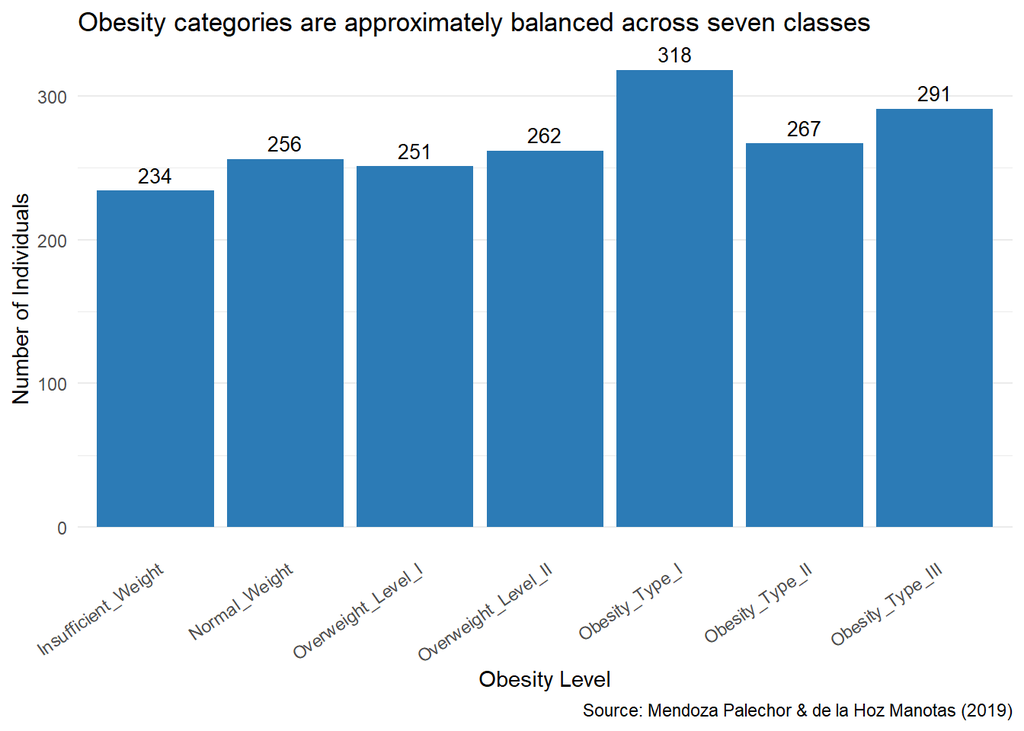

```r
# Plot 1: Outcome class distribution
ggplot(data_clean, aes(x = NObeyesdad)) +
  geom_bar(fill = "#2C7BB6") +
  geom_text(stat = "count", aes(label = after_stat(count)),
            vjust = -0.5, size = 3.5) +
  labs(
    title = "Obesity categories are approximately balanced across seven classes",
    x = "Obesity Level",
    y = "Number of Individuals",
    caption = "Source: Mendoza Palechor & de la Hoz Manotas (2019)"
  ) +
  theme_minimal() +
  theme(axis.text.x = element_text(angle = 35, hjust = 1),
    panel.grid.major.x = element_blank()
  )
```

## 2.2 Class Distribution

Figure 1 shows the distribution of the target variable across seven obesity categories. With numbers ranging from 234 (Insufficient Weight) to 318 (Obesity Type I), the distribution is roughly balanced after SMOTE augmentation. When analysing model performance in Section 4, it is crucial to recognise that this near-balance is an artefact of the synthetic oversampling procedure rather than a representation of actual population prevalence. Obesity groups would be far more unbalanced in real-world population statistics, with normal weight and overweight categories predominating.

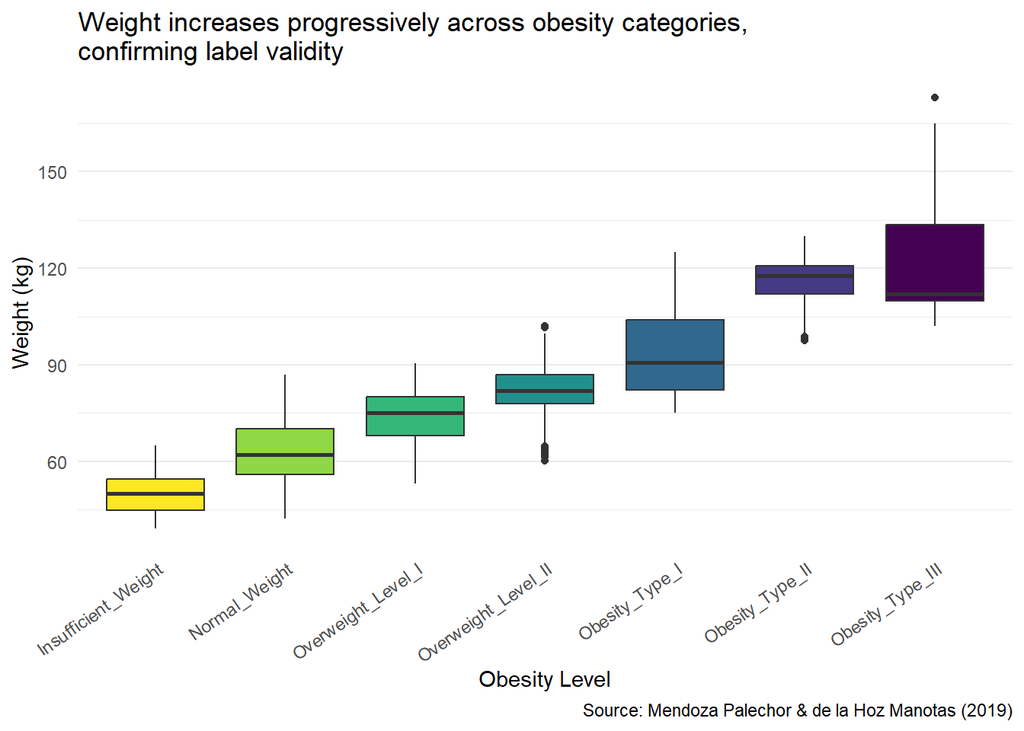

```r
# Plot 2: Weight distribution by obesity class
ggplot(data_clean, aes(x = NObeyesdad, y = Weight, fill = NObeyesdad)) +
  geom_boxplot(show.legend = FALSE) +
  scale_fill_viridis_d(direction = -1) +
  labs(
    title = "Weight increases progressively across obesity categories,\nconfirming label validity",
    x = "Obesity Level",
    y = "Weight (kg)",
    caption = "Source: Mendoza Palechor & de la Hoz Manotas (2019)"
  ) +
  theme_minimal() +
  theme(    axis.text.x = element_text(angle = 35, hjust = 1),
    panel.grid.major.x = element_blank()
  )
```

## 2.3 Weight Distribution Across Obesity Categories

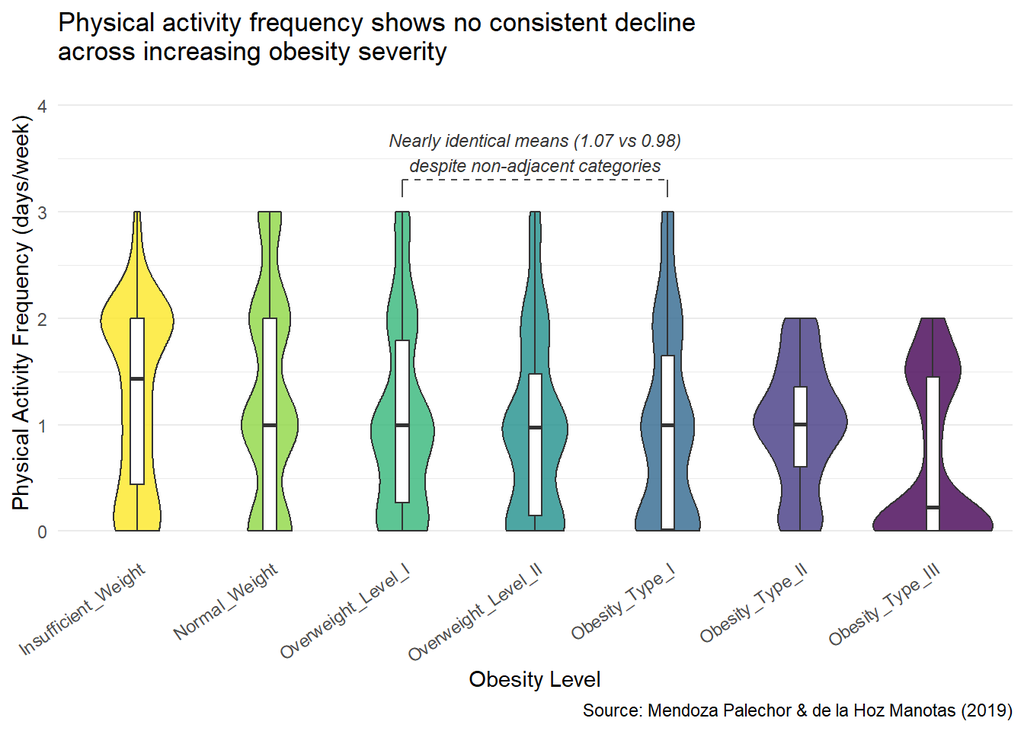

```r
# Plot 3: Physical activity frequency by obesity class
annot_y <- max(data_clean$FAF, na.rm = TRUE) * 1.1

ggplot(data_clean, aes(x = NObeyesdad, y = FAF, fill = NObeyesdad)) +
  geom_violin(show.legend = FALSE, alpha = 0.8) +
  geom_boxplot(width = 0.1, show.legend = FALSE, fill = "white") +
  scale_fill_viridis_d(direction = -1) +
  annotate("segment", x = 3, xend = 5, y = annot_y, yend = annot_y,
           color = "grey30", linetype = "dashed") +
  annotate("segment", x = 3, xend = 3, y = annot_y, yend = annot_y * 0.95,
           color = "grey30") +
  annotate("segment", x = 5, xend = 5, y = annot_y, yend = annot_y * 0.95,
           color = "grey30") +
  annotate("text", x = 4, y = annot_y * 1.08,
           label = "Nearly identical means (1.07 vs 0.98)\ndespite non-adjacent categories",
           size = 3, color = "grey20", fontface = "italic") +
  scale_y_continuous(expand = expansion(mult = c(0.05, 0.2))) +
  labs(
    title = "Physical activity frequency shows no consistent decline\nacross increasing obesity severity",
    x = "Obesity Level",
    y = "Physical Activity Frequency (days/week)",
    caption = "Source: Mendoza Palechor & de la Hoz Manotas (2019)"
  ) +
  theme_minimal() +
  theme(axis.text.x = element_text(angle = 35, hjust = 1),
        panel.grid.major.x = element_blank())
```

## 2.4 Physical Activity Across Obesity Categories

Figure 3 shows physical activity frequency by obesity group, with mean frequency declining overall from around 1.3 days per week (Insufficient Weight) to under 0.7 (Obesity Type III). From the annotation, Overweight Level I and Obesity Type I break this trend with near-identical means despite being non-adjacent categories. The overlapping violin shapes indicate significant within category heterogeneity, indicating that physical activity by itself has little diagnostic value. In order to contribute significantly to classification, it probably requires additional behavioural variables, which are tested directly through variable importance in Section 4.

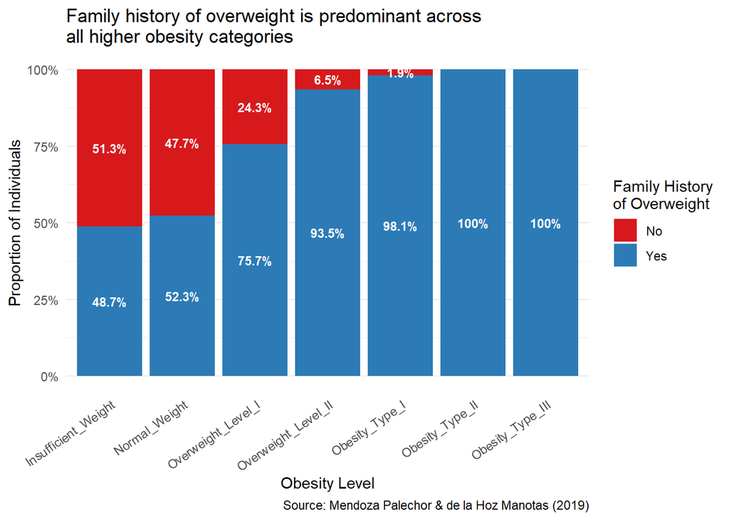

```r
# Plot 4: Family history proportions by obesity class
data_clean %>%
  group_by(NObeyesdad, family_history_with_overweight) %>%
  summarise(n = n(), .groups = "drop") %>%
  group_by(NObeyesdad) %>%
  mutate(prop = n / sum(n)) %>%
  ggplot(aes(x = NObeyesdad, y = prop,
             fill = family_history_with_overweight)) +
  geom_col(position = "stack") +  geom_text(aes(label = paste0(round(prop * 100, 1), "%")),
            position = position_stack(vjust = 0.5),
            color = "white", size = 3, fontface = "bold")+
  scale_fill_manual(
    values = c("yes" = "#2C7BB6", "no" = "#D7191C"),
    labels = c("yes" = "Yes", "no" = "No"),
    name = "Family History\nof Overweight"
  ) +
  scale_y_continuous(labels = scales::percent) +
  labs(
    title = "Family history of overweight is predominant across\nall higher obesity categories",
    x = "Obesity Level",
    y = "Proportion of Individuals",
    caption = "Source: Mendoza Palechor & de la Hoz Manotas (2019)"
  ) +
  theme_minimal() +
  theme(
    axis.text.x = element_text(angle = 35, hjust = 1),
    panel.grid.major.x = element_blank()
  )
```

## 2.5 Family History of Overweight

The proportions are indicated directly on the chart in Figure 4, which displays the family history of overweight by obese category. One of Model A’s most powerful discriminating signals is family history, which climbs from around half in the lowest-weight groups to 100% in Type II and III obesity. Its predictive value, however, refers to shared context rather than a single changeable activity since it probably reflects common family environment and genetic predisposition rather than a real behavioural habit.

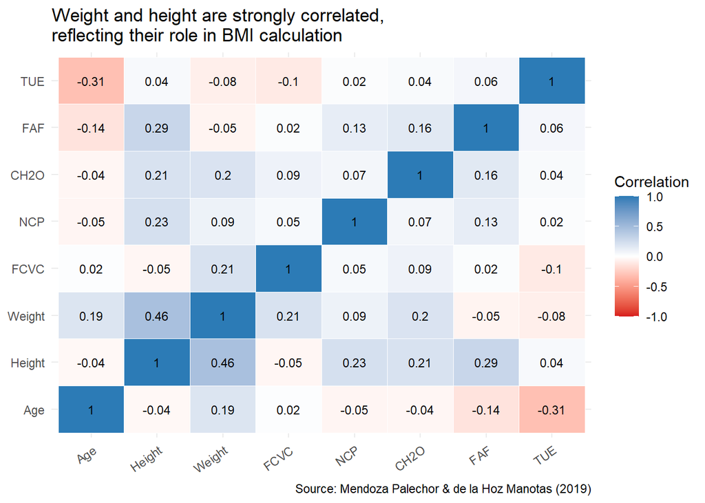

```r
# Plot 5: Correlation heatmap of numeric variables
library(reshape2)
numeric_vars <- data_clean %>%
  select(Age, Height, Weight, FCVC, NCP, CH2O, FAF, TUE)

cor_matrix <- cor(numeric_vars)
cor_melted <- melt(cor_matrix)

ggplot(cor_melted, aes(x = Var1, y = Var2, fill = value)) +
  geom_tile(color = "white") +
  geom_text(aes(label = round(value, 2)), size = 3) +
  scale_fill_gradient2(
    low = "#D7191C", mid = "white", high = "#2C7BB6",
    midpoint = 0, limits = c(-1, 1),
    name = "Correlation"
  ) +
  labs(
    title = "Weight and height are strongly correlated,\nreflecting their role in BMI calculation",
    x = NULL, y = NULL,
    caption = "Source: Mendoza Palechor & de la Hoz Manotas (2019)"
  ) +
  theme_minimal() +
  theme(axis.text.x = element_text(angle = 35, hjust = 1))
```

## 2.6 Correlations Among Continuous Variables

A correlation heatmap of the dataset’s eight continuous variables is shown in Figure 5. Given their common involvement in the BMI calculation that underpins the outcome labels, it is not surprising that weight and height have the greatest association (r = 0.46). The remaining behavioural variables—FCVC, NCP, CH2O, FAF, and TUE—show almost no associations with each other or with the anthropometric factors, although weight and age have a modest positive link (r = 0.19). Model A is reassured by the lack of significant multicollinearity across behavioural predictors, which suggests that these variables provide comparatively independent information to the classification task.

# 3. Statistical Methods

## 3.2 Choice of Method

The classifier for both models was Random Forest (Breiman, 2001). Using bootstrap samples and random predictor subsets at each split, it creates an ensemble of decision trees, integrating predictions by majority vote to lower variance. The dataset’s mixed continuous, binary, and ordinal predictors can be accommodated without significant preparation; it generates permutation-based variable importance scores that allow direct comparison of behavioural and anthropometric predictors across models; it handles seven-class outcomes natively without one-versus-rest decomposition; and it captures the non-linear and non-monotonic relationships observed in the EDA without requiring a specified functional form. Because the results of the EDA violate the linearity assumption of multinomial logistic regression, it was rejected. There are three restrictions: Importance scores indicate predictive contribution rather than causal influence; Random Forest treats the obesity categories as nominal, possibly lacking ordinal structure that could help adjacent-category discrimination; and even though the test set is held out before modelling, performance may still be inflated by the similarity between synthetic training and test observations produced by SMOTE.

## 3.3 Model Evaluation

A classifier may perform well on the larger Obesity Type I category while incorrectly classifying smaller ones like Insufficient Weight, with little impact on the headline figure, even though SMOTE has made class sizes generally comparable (234–318 observations). As a result, four complementing measures were employed. The percentage of properly identified observations is provided by overall accuracy. By averaging per-class recall, balanced accuracy assigns equal weight to all categories, regardless of size. The harmonic mean of accuracy and recall, or per-class F1 scores, show which particular categories are most difficult to describe. Finally, confusion matrices were utilised to show precisely which category pairs produce the mistakes since misclassifying nearby severity categories (such as Overweight Level I as Overweight Level II) is qualitatively less problematic than mistaking distant ones (such as Normal Weight as Obesity Type III).

```r
library(randomForest)
library(caret)
```

```r
set.seed(23011967)
train_index <- createDataPartition(data_clean$NObeyesdad,
                                    p = 0.8, list = FALSE)
train_data <- data_clean[train_index, ]
test_data  <- data_clean[-train_index, ]

model_A_vars <- c("Gender", "Age", "family_history_with_overweight",
                  "FAVC", "FCVC", "NCP", "CAEC", "SMOKE", "CH2O",
                  "SCC", "FAF", "TUE", "CALC", "MTRANS", "NObeyesdad")

train_A <- train_data[, model_A_vars]
test_A  <- test_data[, model_A_vars]
train_B <- train_data
test_B  <- test_data

rf_A <- randomForest(NObeyesdad ~ ., data = train_A,
                     ntree = 500, importance = TRUE)
rf_B <- randomForest(NObeyesdad ~ ., data = train_B,
                     ntree = 500, importance = TRUE)

pred_A <- predict(rf_A, test_A)
pred_B <- predict(rf_B, test_B)

cm_A <- confusionMatrix(pred_A, test_A$NObeyesdad)
cm_B <- confusionMatrix(pred_B, test_B$NObeyesdad)

bal_acc_A <- mean(cm_A$byClass[, "Balanced Accuracy"])
bal_acc_B <- mean(cm_B$byClass[, "Balanced Accuracy"])
```

```r
cm_A_df <- as.data.frame(cm_A$table) %>%
  rename(Predicted = Prediction, Actual = Reference)

cm_B_df <- as.data.frame(cm_B$table) %>%
  rename(Predicted = Prediction, Actual = Reference)

short_labels <- c(
  "Insufficient_Weight" = "Insuff.",
  "Normal_Weight"       = "Normal",
  "Overweight_Level_I"  = "OW I",
  "Overweight_Level_II" = "OW II",
  "Obesity_Type_I"      = "Ob I",
  "Obesity_Type_II"     = "Ob II",
  "Obesity_Type_III"    = "Ob III"
)
```

# Section 4 - Results and Data Communication [30%]

## 4.1 Model Performance Comparison

```r
# Overall accuracy
cat("Model A Accuracy:", round(cm_A$overall["Accuracy"], 4), "\n")
```

```
## Model A Accuracy: 0.8177
```

```r
cat("Model B Accuracy:", round(cm_B$overall["Accuracy"], 4), "\n")
```

```
## Model B Accuracy: 0.9357
```

```r
# Balanced accuracy
cat("Model A Balanced Accuracy:",
    round(mean(cm_A$byClass[,"Balanced Accuracy"]), 4), "\n")
```

```
## Model A Balanced Accuracy: 0.8919
```

```r
cat("Model B Balanced Accuracy:",
    round(mean(cm_B$byClass[,"Balanced Accuracy"]), 4), "\n")
```

```
## Model B Balanced Accuracy: 0.9604
```

```r
# Per class F1 scores
cat("\nModel A F1 Scores:\n")
```

```
##
## Model A F1 Scores:
```

```r
print(round(cm_A$byClass[,"F1"], 4))
```

```
## Class: Insufficient_Weight       Class: Normal_Weight
##                     0.8764                     0.6885
##  Class: Overweight_Level_I Class: Overweight_Level_II
##                     0.7765                     0.7010
##      Class: Obesity_Type_I     Class: Obesity_Type_II
##                     0.8254                     0.8649
##    Class: Obesity_Type_III
##                     0.9828
```

```r
cat("\nModel B F1 Scores:\n")
```

```
##
## Model B F1 Scores:
```

```r
print(round(cm_B$byClass[,"F1"], 4))
```

```
## Class: Insufficient_Weight       Class: Normal_Weight
##                     0.9302                     0.8596
##  Class: Overweight_Level_I Class: Overweight_Level_II
##                     0.8571                     0.9444
##      Class: Obesity_Type_I     Class: Obesity_Type_II
##                     0.9841                     0.9714
##    Class: Obesity_Type_III
##                     0.9828
```

```r
# Variable importance for both models
importance_A <- importance(rf_A, type = 1) %>%
  as.data.frame() %>%
  rownames_to_column("Variable") %>%
  rename(Importance = MeanDecreaseAccuracy) %>%
  arrange(desc(Importance))

importance_B <- importance(rf_B, type = 1) %>%
  as.data.frame() %>%
  rownames_to_column("Variable") %>%
  rename(Importance = MeanDecreaseAccuracy) %>%
  arrange(desc(Importance))

print(importance_A)
```

```
##                          Variable Importance
## 1                            FCVC  79.688886
## 2                             Age  72.787844
## 3                          Gender  72.652038
## 4  family_history_with_overweight  56.963610
## 5                             NCP  54.253239
## 6                            CH2O  52.720705
## 7                             FAF  49.189697
## 8                             TUE  46.052564
## 9                            CALC  46.032847
## 10                           CAEC  43.474616
## 11                         MTRANS  39.288266
## 12                           FAVC  35.264692
## 13                            SCC  25.093284
## 14                          SMOKE   6.756052
```

```r
print(importance_B)
```

```
##                          Variable Importance
## 1                          Weight 117.393136
## 2                          Height  52.376088
## 3                             Age  48.628199
## 4                          Gender  38.856041
## 5                            FCVC  37.197141
## 6                            CH2O  36.906965
## 7                             NCP  33.682967
## 8                             TUE  31.734798
## 9                             FAF  31.712536
## 10 family_history_with_overweight  28.467624
## 11                           CAEC  26.693689
## 12                           FAVC  26.461064
## 13                           CALC  25.955171
## 14                         MTRANS  24.466958
## 15                            SCC  13.226390
## 16                          SMOKE   1.674521
```

Overall accuracy rises from 81.8% to 93.6% when height and weight are included. Behavioural variables alone place the majority of individuals within one severity band of their true category a level of accuracy that has real screening implications even without a scale or tape measure. Adding height and weight narrows that gap further, but the 11.8 percentage point difference in overall accuracy reveals that physical measurements contribute a concentrated predictive signal that behavioural information alone cannot replicate.

Balanced accuracy — which accounts for differential performance across the seven obesity categories — tells a similar story, rising from 89.2% in Model A to 96.0% in Model B. The gap between overall and balanced accuracy in Model A (81.8% vs 89.2%) reflects the fact that Model A struggles disproportionately with certain middle categories. Crucially, both figures should be interpreted in the context of the dataset’s construction: 77% of observations are synthetically generated via SMOTE, and performance estimates on synthetic test observations likely overstate the accuracy that would be achieved on genuinely observed clinical data.

```r
perf_table <- tibble(
  Metric = c("Overall Accuracy", "Balanced Accuracy",
             "F1 — Insufficient Weight", "F1 — Normal Weight",
             "F1 — Overweight Level I", "F1 — Overweight Level II",
             "F1 — Obesity Type I", "F1 — Obesity Type II",
             "F1 — Obesity Type III"),
  `Model A (Behavioural)` = c("81.8%", "89.2%",
                               "0.876", "0.689", "0.777",
                               "0.701", "0.825", "0.865", "0.983"),
  `Model B (All Predictors)` = c("93.6%", "96.0%",
                                  "0.930", "0.860", "0.857",
                                  "0.944", "0.984", "0.971", "0.983")
)
knitr::kable(perf_table,
             caption = "Table 2: Model performance comparison across all evaluation metrics")
```

Table 2: Model performance comparison across all evaluation metrics

| Metric | Model A (Behavioural) | Model B (All Predictors) |
| --- | --- | --- |
| Overall Accuracy | 81.8% | 93.6% |
| Balanced Accuracy | 89.2% | 96.0% |
| F1 — Insufficient Weight | 0.876 | 0.930 |
| F1 — Normal Weight | 0.689 | 0.860 |
| F1 — Overweight Level I | 0.777 | 0.857 |
| F1 — Overweight Level II | 0.701 | 0.944 |
| F1 — Obesity Type I | 0.825 | 0.984 |
| F1 — Obesity Type II | 0.865 | 0.971 |
| F1 — Obesity Type III | 0.983 | 0.983 |

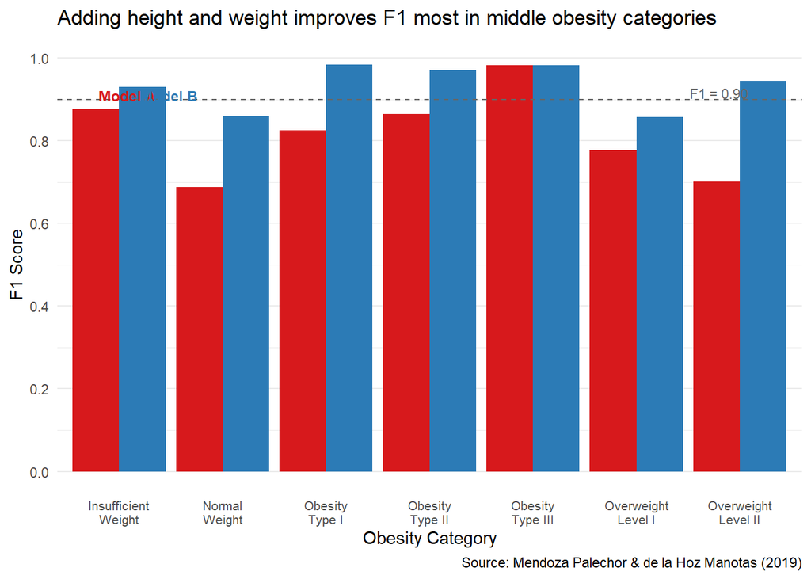

Figure 6: Per-class F1 scores for Model A and Model B across seven obesity categories.

```r
# Add model label annotations directly to first category bars
# instead of using fill legend

f1_data <- tibble(
  Category = rep(c("Insufficient\nWeight", "Normal\nWeight",
                   "Overweight\nLevel I", "Overweight\nLevel II",
                   "Obesity\nType I", "Obesity\nType II",
                   "Obesity\nType III"), 2),
  F1 = c(0.8764, 0.6885, 0.7765, 0.7010, 0.8254, 0.8649, 0.9828,
          0.9302, 0.8596, 0.8571, 0.9444, 0.9841, 0.9714, 0.9828),
  Model = rep(c("Model A: Behavioural Only",
                "Model B: All Predictors"), each = 7)
)

ggplot(f1_data, aes(x = Category, y = F1, fill = Model)) +
  geom_col(position = "dodge") +
  geom_hline(yintercept = 0.9, linetype = "dashed",
             color = "grey40", linewidth = 0.5) +
  scale_fill_manual(values = c(
    "Model A: Behavioural Only" = "#D7191C",
    "Model B: All Predictors"   = "#2C7BB6"
  )) +
  annotate("text", x = 0.8, y = 0.91,
           label = "Model A", color = "#D7191C",
           fontface = "bold", size = 3.2, hjust = 0) +
  annotate("text", x = 1.2, y = 0.91,
           label = "Model B", color = "#2C7BB6",
           fontface = "bold", size = 3.2, hjust = 0) +
  scale_y_continuous(limits = c(0, 1),
                     breaks = seq(0, 1, 0.2),
                     labels = scales::number_format(accuracy = 0.1)) +
  annotate("text", x = 6.8, y = 0.915,
           label = "F1 = 0.90", size = 3, color = "grey40") +
  labs(
    title = "Adding height and weight improves F1 most in middle obesity categories",
    x = "Obesity Category",
    y = "F1 Score",
    caption = "Source: Mendoza Palechor & de la Hoz Manotas (2019)"
  ) +
  theme_minimal() +
  theme(
    legend.position = "none",   # <-- remove legend
    panel.grid.major.x = element_blank(),
    axis.text.x = element_text(size = 8)
  )
```

## 4.2 Per Class Performance

Per-class F1 scores for both models in each of the seven obesity categories are shown in Figure 6. Performance in Model A differs significantly between classes. Normal Weight (F1 = 0.69) and Overweight Level II (F1 = 0.70), which both occupy intermediate places in the obesity severity continuum where behavioural signals are most unclear and overlapping, are the two most challenging groups to diagnose. Obesity Type III, on the other hand, obtains an F1 of 0.98 in Model A, indicating that the most extreme obesity group is sufficiently unique in behaviour to be consistently diagnosed without physical measures.

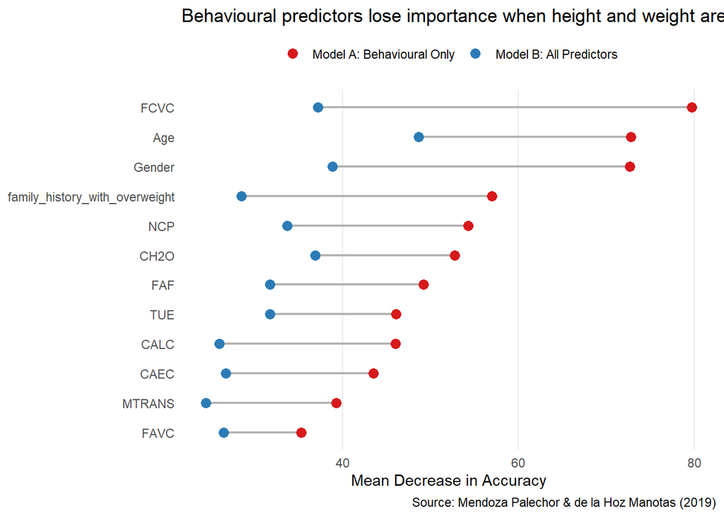

Figure 7: Variable importance scores (mean decrease in accuracy) for Model A and Model B.

```r
library(ggplot2)
library(dplyr)

# Get shared variables between both models (all of Model A's vars appear in B)
imp_combined <- importance_A %>%
  rename(Imp_A = Importance) %>%
  inner_join(importance_B %>% rename(Imp_B = Importance), by = "Variable") %>%
  mutate(delta = Imp_B - Imp_A) %>%
  arrange(desc(Imp_A)) %>%
  slice_head(n = 12)   # top 12 by Model A importance

imp_long <- imp_combined %>%
  pivot_longer(cols = c(Imp_A, Imp_B),
               names_to = "Model", values_to = "Importance") %>%
  mutate(Model = recode(Model,
    "Imp_A" = "Model A: Behavioural Only",
    "Imp_B" = "Model B: All Predictors"
  ))

ggplot() +
  # connecting line between the two dots for each variable
  geom_segment(data = imp_combined,
               aes(x = Imp_A, xend = Imp_B,
                   y = reorder(Variable, Imp_A), yend = reorder(Variable, Imp_A)),
               color = "grey70", linewidth = 0.8) +
  # dots
  geom_point(data = imp_long,
             aes(x = Importance,
                 y = reorder(Variable, Importance),
                 color = Model),
             size = 3) +
  scale_color_manual(values = c(
    "Model A: Behavioural Only" = "#D7191C",
    "Model B: All Predictors"   = "#2C7BB6"
  )) +
  labs(
    title = "Behavioural predictors lose importance when height and weight are added",
    x = "Mean Decrease in Accuracy",
    y = NULL,
    color = NULL,
    caption = "Source: Mendoza Palechor & de la Hoz Manotas (2019)"
  ) +
  theme_minimal() +
  theme(
    legend.position = "top",
    panel.grid.major.y = element_blank(),
    panel.grid.minor.x = element_blank()
  )
```

## 4.3 Variable Importance

Weight alone has a significance score of 117.4 in Model B, which is more than twice as high as the next predictor, height (52.4). All behavioural factors lose significant weight when physical measures are taken into account: family history declines from 57.0 to 28.5 and FCVC drops from 79.7 in Model A to 37.2 in Model B. This trend is completely compatible with the way the dataset was constructed because the result is mathematically encoded by height and weight, which were used to produce NObesity labels straight from the BMI calculation. Therefore, the variable significance plot shows an artefact of label production rather than a true clinical finding: In part, Model B is rediscovering the target variable’s creation formula.

[figure not shown]

Figure 8: Confusion matrix for Model A — behavioural predictors only.

```r
cm_A_df %>%
  mutate(
    Predicted = recode(Predicted, !!!short_labels),
    Actual    = recode(Actual,    !!!short_labels),
    Predicted = factor(Predicted, levels = short_labels),
    Actual    = factor(Actual,    levels = short_labels),
    on_diag   = Predicted == Actual          # <-- flag diagonal
  ) %>%
  ggplot(aes(x = Actual, y = Predicted, fill = Freq)) +
  geom_tile(aes(color = on_diag, linewidth = on_diag)) +  # highlight border
  geom_text(aes(label = Freq), size = 3.5) +
  scale_fill_gradient(low = "white", high = "#D7191C", name = "Count") +
  scale_color_manual(values = c("TRUE" = "black", "FALSE" = "white"),
                     guide = "none") +
  scale_linewidth_manual(values = c("TRUE" = 1.2, "FALSE" = 0.3),
                         guide = "none") +
  labs(
    title = "Model A misclassification concentrates between adjacent obesity categories",
    x = "Actual Category", y = "Predicted Category",
    caption = "Source: Mendoza Palechor & de la Hoz Manotas (2019)"
  ) +
  theme_minimal() +
  theme(axis.text.x = element_text(angle = 35, hjust = 1))
```

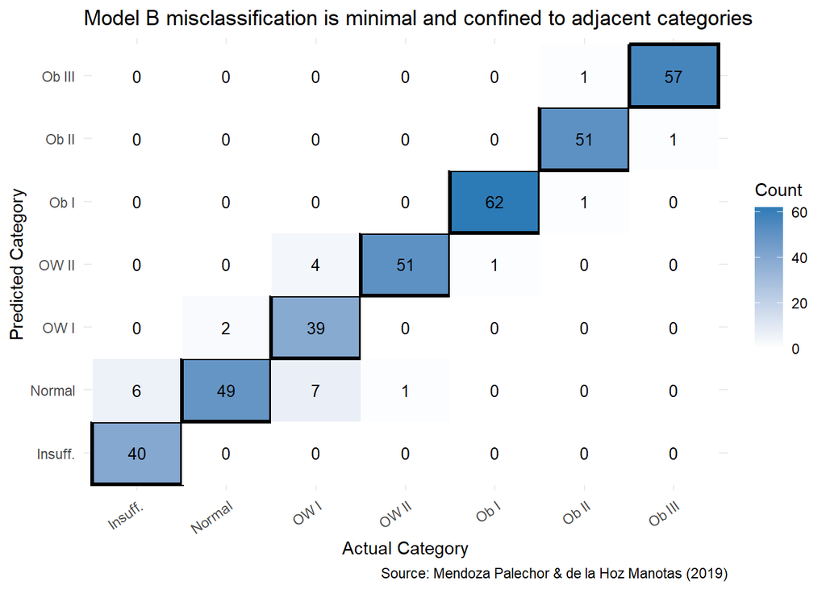

Figure 9: Confusion matrix for Model B — all predictors including height and weight.

```r
# Confusion matrix Model B
cm_B_df %>%
  mutate(
    Predicted = recode(Predicted, !!!short_labels),
    Actual    = recode(Actual,    !!!short_labels),
    Predicted = factor(Predicted, levels = short_labels),
    Actual    = factor(Actual,    levels = short_labels),
    on_diag   = Predicted == Actual
  ) %>%
  ggplot(aes(x = Actual, y = Predicted, fill = Freq)) +
  geom_tile(aes(color = on_diag, linewidth = on_diag)) +
  geom_text(aes(label = Freq), size = 3.5) +
  scale_fill_gradient(low = "white", high = "#2C7BB6", name = "Count") +
  scale_color_manual(values = c("TRUE" = "black", "FALSE" = "white"),
                     guide = "none") +
  scale_linewidth_manual(values = c("TRUE" = 1.2, "FALSE" = 0.3),
                         guide = "none") +
  labs(
    title = "Model B misclassification is minimal and confined to adjacent categories",
    x = "Actual Category",
    y = "Predicted Category",
    caption = "Source: Mendoza Palechor & de la Hoz Manotas (2019)"
  ) +
  theme_minimal() +
  theme(axis.text.x = element_text(angle = 35, hjust = 1))
```

# Section 5

## 5a Before-and-After Visual Comparison

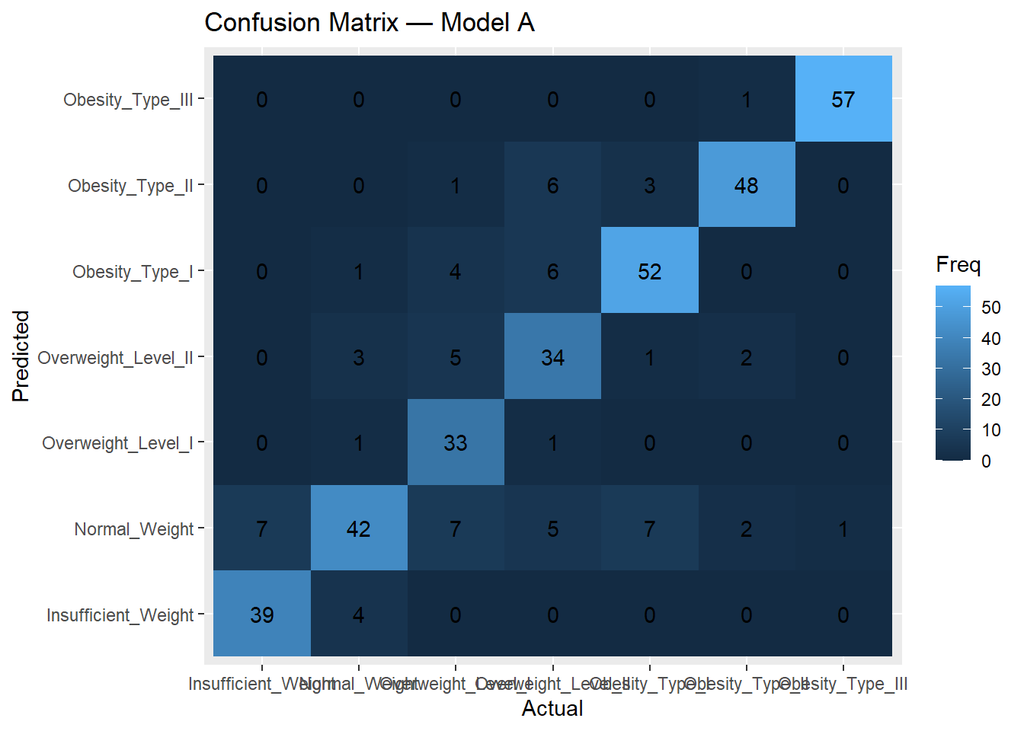

Figure 10: Default confusion matrix output before design improvements.

```r
# BEFORE version — default ggplot confusion matrix
cm_A_df %>%
  ggplot(aes(x = Actual, y = Predicted, fill = Freq)) +
  geom_tile() +
  geom_text(aes(label = Freq)) +
  labs(title = "Confusion Matrix — Model A")
```

## 5c Connection to Module Principles

Throughout, the affordance principle influenced the choice of chart type. The stacked bar chart in Figure 4 encodes family history proportions with a constant zero baseline, making it easy to see how the obesity categories have increased. A grouped bar chart was utilised in an earlier draft, which made within-category comparison easier while hiding the true finding—a cross-category trend. This choice was immediately altered by realising that the type of chart dictates which comparisons felt natural. The clearance of clutter was done regularly. Gridlines on both axes, a grey panel backdrop, and legends that frequently overlap data are features of the default ggplot2 output. Each map eliminates category-axis gridlines, has a simple backdrop, and, if feasible, substitutes direct labels for legends. Colour selections were also influenced by accessibility: the red-blue combination was chosen in part because, in contrast to red-green pairings, it is still identifiable under deuteranopia, supporting the idea that design shouldn’t unintentionally exclude readers.

## 5d Analytical Limitations

There are four restrictions that call for prudence. First, SMOTE created 77% of the artificial observations before to the train-test split. Accuracy on this test set probably overstates performance on really observed clinical data since synthetic observations are constructed to match its real neighbours; hence, all measures should be regarded as upper bounds rather than clinical usefulness estimates. Second, NObesity labels were determined deterministically using BMI based on height and weight. Therefore, rather than exhibiting true predictive ability, Model B only partially recovers the formula used to get the result. Without this context, a reader would mistakenly believe that physical measures are powerful independent indicators of obesity based on its 93.6% accuracy. Third, the dataset’s generalisability to other demographics and clinical contexts is limited since it is geographically limited to Mexico, Peru, and Colombia using an online convenience sample. Lastly, Random Forest ignores the natural severity ordering of obesity categories by considering them as nominal means, and an ordinal classifier may result in very different misclassification patterns for neighbouring categories.